# 7: Data frames and linear regression

R for faculty, Fall 2024

Jonas Moss

# Data frames

## Data frames

- Info
- Information
- Access
- Subframes
- Assignment
- Exercise
- Solution
- Exercise
- Solution

A *data frame* is like an Excel sheet. Used for tabular data.

```r
head(mtcars)
```

```
                   mpg cyl disp  hp drat    wt  qsec vs am gear carb
Mazda RX4         21.0   6  160 110 3.90 2.620 16.46  0  1    4    4
Mazda RX4 Wag     21.0   6  160 110 3.90 2.875 17.02  0  1    4    4
Datsun 710        22.8   4  108  93 3.85 2.320 18.61  1  1    4    1
Hornet 4 Drive    21.4   6  258 110 3.08 3.215 19.44  1  0    3    1
Hornet Sportabout 18.7   8  360 175 3.15 3.440 17.02  0  0    3    2
Valiant           18.1   6  225 105 2.76 3.460 20.22  1  0    3    1
```

```r
class(mtcars)
```

```
[1] "data.frame"
```

A data frame is, more or less, a list whose named elements are vectors of the same length.

```r
dim(mtcars)
```

```
[1] 32 11
```

Access a vector with `$`:

```r
mtcars$mpg
```

```
 [1] 21.0 21.0 22.8 21.4 18.7 18.1 14.3 24.4 22.8 19.2 17.8 16.4 17.3 15.2 10.4
[16] 10.4 14.7 32.4 30.4 33.9 21.5 15.5 15.2 13.3 19.2 27.3 26.0 30.4 15.8 19.7
[31] 15.0 21.4
```

Or by double square brackets:

```r
mtcars[["mpg"]]
```

```
 [1] 21.0 21.0 22.8 21.4 18.7 18.1 14.3 24.4 22.8 19.2 17.8 16.4 17.3 15.2 10.4
[16] 10.4 14.7 32.4 30.4 33.9 21.5 15.5 15.2 13.3 19.2 27.3 26.0 30.4 15.8 19.7
[31] 15.0 21.4
```

Using single squared brackets return a data frame!

```r
mtcars["mpg"]
```

```
                     mpg
Mazda RX4           21.0
Mazda RX4 Wag       21.0
Datsun 710          22.8
Hornet 4 Drive      21.4
Hornet Sportabout   18.7
Valiant             18.1
Duster 360          14.3
Merc 240D           24.4
Merc 230            22.8
Merc 280            19.2
Merc 280C           17.8
Merc 450SE          16.4
Merc 450SL          17.3
Merc 450SLC         15.2
Cadillac Fleetwood  10.4
Lincoln Continental 10.4
Chrysler Imperial   14.7
Fiat 128            32.4
Honda Civic         30.4
Toyota Corolla      33.9
Toyota Corona       21.5
Dodge Challenger    15.5
AMC Javelin         15.2
Camaro Z28          13.3
Pontiac Firebird    19.2
Fiat X1-9           27.3
Porsche 914-2       26.0
Lotus Europa        30.4
Ford Pantera L      15.8
Ferrari Dino        19.7
Maserati Bora       15.0
Volvo 142E          21.4
```

Extract subframes using lists:

```r
mtcars[c("mpg", "wt", "cyl")]
```

```
                     mpg    wt cyl
Mazda RX4           21.0 2.620   6
Mazda RX4 Wag       21.0 2.875   6
Datsun 710          22.8 2.320   4
Hornet 4 Drive      21.4 3.215   6
Hornet Sportabout   18.7 3.440   8
Valiant             18.1 3.460   6
Duster 360          14.3 3.570   8
Merc 240D           24.4 3.190   4
Merc 230            22.8 3.150   4
Merc 280            19.2 3.440   6
Merc 280C           17.8 3.440   6
Merc 450SE          16.4 4.070   8
Merc 450SL          17.3 3.730   8
Merc 450SLC         15.2 3.780   8
Cadillac Fleetwood  10.4 5.250   8
Lincoln Continental 10.4 5.424   8
Chrysler Imperial   14.7 5.345   8
Fiat 128            32.4 2.200   4
Honda Civic         30.4 1.615   4
Toyota Corolla      33.9 1.835   4
Toyota Corona       21.5 2.465   4
Dodge Challenger    15.5 3.520   8
AMC Javelin         15.2 3.435   8
Camaro Z28          13.3 3.840   8
Pontiac Firebird    19.2 3.845   8
Fiat X1-9           27.3 1.935   4
Porsche 914-2       26.0 2.140   4
Lotus Europa        30.4 1.513   4
Ford Pantera L      15.8 3.170   8
Ferrari Dino        19.7 2.770   6
Maserati Bora       15.0 3.570   8
Volvo 142E          21.4 2.780   4
```

You can assign vectors in the intuitive way:

```r
mtnew <- mtcars
mtnew$x <- 2*mtcars$cyl + mtcars$mpg
```

Data frames are *not* arrays, but can often by converted to them:

```r
as.matrix(mtcars)
```

```
                     mpg cyl  disp  hp drat    wt  qsec vs am gear carb
Mazda RX4           21.0   6 160.0 110 3.90 2.620 16.46  0  1    4    4
Mazda RX4 Wag       21.0   6 160.0 110 3.90 2.875 17.02  0  1    4    4
Datsun 710          22.8   4 108.0  93 3.85 2.320 18.61  1  1    4    1
Hornet 4 Drive      21.4   6 258.0 110 3.08 3.215 19.44  1  0    3    1
Hornet Sportabout   18.7   8 360.0 175 3.15 3.440 17.02  0  0    3    2
Valiant             18.1   6 225.0 105 2.76 3.460 20.22  1  0    3    1
Duster 360          14.3   8 360.0 245 3.21 3.570 15.84  0  0    3    4
Merc 240D           24.4   4 146.7  62 3.69 3.190 20.00  1  0    4    2
Merc 230            22.8   4 140.8  95 3.92 3.150 22.90  1  0    4    2
Merc 280            19.2   6 167.6 123 3.92 3.440 18.30  1  0    4    4
Merc 280C           17.8   6 167.6 123 3.92 3.440 18.90  1  0    4    4
Merc 450SE          16.4   8 275.8 180 3.07 4.070 17.40  0  0    3    3
Merc 450SL          17.3   8 275.8 180 3.07 3.730 17.60  0  0    3    3
Merc 450SLC         15.2   8 275.8 180 3.07 3.780 18.00  0  0    3    3
Cadillac Fleetwood  10.4   8 472.0 205 2.93 5.250 17.98  0  0    3    4
Lincoln Continental 10.4   8 460.0 215 3.00 5.424 17.82  0  0    3    4
Chrysler Imperial   14.7   8 440.0 230 3.23 5.345 17.42  0  0    3    4
Fiat 128            32.4   4  78.7  66 4.08 2.200 19.47  1  1    4    1
Honda Civic         30.4   4  75.7  52 4.93 1.615 18.52  1  1    4    2
Toyota Corolla      33.9   4  71.1  65 4.22 1.835 19.90  1  1    4    1
Toyota Corona       21.5   4 120.1  97 3.70 2.465 20.01  1  0    3    1
Dodge Challenger    15.5   8 318.0 150 2.76 3.520 16.87  0  0    3    2
AMC Javelin         15.2   8 304.0 150 3.15 3.435 17.30  0  0    3    2
Camaro Z28          13.3   8 350.0 245 3.73 3.840 15.41  0  0    3    4
Pontiac Firebird    19.2   8 400.0 175 3.08 3.845 17.05  0  0    3    2
Fiat X1-9           27.3   4  79.0  66 4.08 1.935 18.90  1  1    4    1
Porsche 914-2       26.0   4 120.3  91 4.43 2.140 16.70  0  1    5    2
Lotus Europa        30.4   4  95.1 113 3.77 1.513 16.90  1  1    5    2
Ford Pantera L      15.8   8 351.0 264 4.22 3.170 14.50  0  1    5    4
Ferrari Dino        19.7   6 145.0 175 3.62 2.770 15.50  0  1    5    6
Maserati Bora       15.0   8 301.0 335 3.54 3.570 14.60  0  1    5    8
Volvo 142E          21.4   4 121.0 109 4.11 2.780 18.60  1  1    4    2
```

Add the column `y`, defined as 2*mpg + cyl, to the `mtnew` data frame.

Remove the columns `disp` and `hp` from `mtnew` by assigning `NULL` to them.

```r
mtnew$disp <- NULL
mtnew$hp <- NULL
```

## Accessing with indices

- Numerical indexing
- Tail and head
- Exercise
- Solution
- Exercise
- Solution
- Exercise
- Solution

It’s often handy to access columns, and rows, using numeric indices.

Index columns like this:

```r
mtcars[, 4] #mtcar$hp
```

```
 [1] 110 110  93 110 175 105 245  62  95 123 123 180 180 180 205 215 230  66  52
[20]  65  97 150 150 245 175  66  91 113 264 175 335 109
```

Rows like this:

```r
mtcars[1:3, ] #three first rows.
```

```
               mpg cyl disp  hp drat    wt  qsec vs am gear carb
Mazda RX4     21.0   6  160 110 3.90 2.620 16.46  0  1    4    4
Mazda RX4 Wag 21.0   6  160 110 3.90 2.875 17.02  0  1    4    4
Datsun 710    22.8   4  108  93 3.85 2.320 18.61  1  1    4    1
```

You can index from the bottom up using `tail`.

```r
tail(mtcars$mpg, 5)
```

```
[1] 30.4 15.8 19.7 15.0 21.4
```

From the top, use `head`.

```r
head(mtcars$mpg, 3)
```

```
[1] 21.0 21.0 22.8
```

Find the `wt` of the five first rows using numeric indexing.

```r
mtcars[1:5, 6]
```

```
[1] 2.620 2.875 2.320 3.215 3.440
```

Find the `wt` of the 3rd, 4th, and 5th row.

```r
mtcars[3:5, 6]
```

```
[1] 2.320 3.215 3.440
```

Find the `wt` and `carb` of the five last elements

```r
tail(mtcars[c("wt", "carb")],5)
```

```
                  wt carb
Lotus Europa   1.513    2
Ford Pantera L 3.170    4
Ferrari Dino   2.770    6
Maserati Bora  3.570    8
Volvo 142E     2.780    2
```

# Linear regression

## Marketing data

```r
marketing <- datarium::marketing
head(marketing)
```

```
  youtube facebook newspaper sales
1  276.12    45.36     83.04 26.52
2   53.40    47.16     54.12 12.48
3   20.64    55.08     83.16 11.16
4  181.80    49.56     70.20 22.20
5  216.96    12.96     70.08 15.48
6   10.44    58.68     90.00  8.64
```

## Running a regression

We run a linear regression using *formulas*.

```r
marketing <- datarium::marketing
model <- lm(sales ~ youtube + facebook + newspaper, data = marketing)
model
```

```
Call:
lm(formula = sales ~ youtube + facebook + newspaper, data = marketing)

Coefficients:
(Intercept)      youtube     facebook    newspaper
   3.526667     0.045765     0.188530    -0.001037
```

## Summary

- Summmary
- Exercise
- Solution
- Exercise
- Solution

Most important information is contained in the `summary(model)` object.

```r
summary(model)
```

```
Call:
lm(formula = sales ~ youtube + facebook + newspaper, data = marketing)

Residuals:
     Min       1Q   Median       3Q      Max
-10.5932  -1.0690   0.2902   1.4272   3.3951

Coefficients:
             Estimate Std. Error t value Pr(>|t|)
(Intercept)  3.526667   0.374290   9.422   <2e-16 ***
youtube      0.045765   0.001395  32.809   <2e-16 ***
facebook     0.188530   0.008611  21.893   <2e-16 ***
newspaper   -0.001037   0.005871  -0.177     0.86
---
Signif. codes:  0 '***' 0.001 '**' 0.01 '*' 0.05 '.' 0.1 ' ' 1

Residual standard error: 2.023 on 196 degrees of freedom
Multiple R-squared:  0.8972,    Adjusted R-squared:  0.8956
F-statistic: 570.3 on 3 and 196 DF,  p-value: < 2.2e-16
```

Inspect the model summary using `str`. Extract the adjusted $R^2$ from the model.

```r
summary(model)$adj.r.squared
```

```
[1] 0.8956373
```

Use `str` on the model summary and the model itself to extract the residuals of the model.

```r
resid(model) == model$residuals
```

```
   1    2    3    4    5    6    7    8    9   10   11   12   13   14   15   16
TRUE TRUE TRUE TRUE TRUE TRUE TRUE TRUE TRUE TRUE TRUE TRUE TRUE TRUE TRUE TRUE
  17   18   19   20   21   22   23   24   25   26   27   28   29   30   31   32
TRUE TRUE TRUE TRUE TRUE TRUE TRUE TRUE TRUE TRUE TRUE TRUE TRUE TRUE TRUE TRUE
  33   34   35   36   37   38   39   40   41   42   43   44   45   46   47   48
TRUE TRUE TRUE TRUE TRUE TRUE TRUE TRUE TRUE TRUE TRUE TRUE TRUE TRUE TRUE TRUE
  49   50   51   52   53   54   55   56   57   58   59   60   61   62   63   64
TRUE TRUE TRUE TRUE TRUE TRUE TRUE TRUE TRUE TRUE TRUE TRUE TRUE TRUE TRUE TRUE
  65   66   67   68   69   70   71   72   73   74   75   76   77   78   79   80
TRUE TRUE TRUE TRUE TRUE TRUE TRUE TRUE TRUE TRUE TRUE TRUE TRUE TRUE TRUE TRUE
  81   82   83   84   85   86   87   88   89   90   91   92   93   94   95   96
TRUE TRUE TRUE TRUE TRUE TRUE TRUE TRUE TRUE TRUE TRUE TRUE TRUE TRUE TRUE TRUE
  97   98   99  100  101  102  103  104  105  106  107  108  109  110  111  112
TRUE TRUE TRUE TRUE TRUE TRUE TRUE TRUE TRUE TRUE TRUE TRUE TRUE TRUE TRUE TRUE
 113  114  115  116  117  118  119  120  121  122  123  124  125  126  127  128
TRUE TRUE TRUE TRUE TRUE TRUE TRUE TRUE TRUE TRUE TRUE TRUE TRUE TRUE TRUE TRUE
 129  130  131  132  133  134  135  136  137  138  139  140  141  142  143  144
TRUE TRUE TRUE TRUE TRUE TRUE TRUE TRUE TRUE TRUE TRUE TRUE TRUE TRUE TRUE TRUE
 145  146  147  148  149  150  151  152  153  154  155  156  157  158  159  160
TRUE TRUE TRUE TRUE TRUE TRUE TRUE TRUE TRUE TRUE TRUE TRUE TRUE TRUE TRUE TRUE
 161  162  163  164  165  166  167  168  169  170  171  172  173  174  175  176
TRUE TRUE TRUE TRUE TRUE TRUE TRUE TRUE TRUE TRUE TRUE TRUE TRUE TRUE TRUE TRUE
 177  178  179  180  181  182  183  184  185  186  187  188  189  190  191  192
TRUE TRUE TRUE TRUE TRUE TRUE TRUE TRUE TRUE TRUE TRUE TRUE TRUE TRUE TRUE TRUE
 193  194  195  196  197  198  199  200
TRUE TRUE TRUE TRUE TRUE TRUE TRUE TRUE
```

## Generic functions

- Generics
- Exercise
- Exercise
- Solution

Linear regression, and many other models, support the generic functions `predict`, `coef`, and `resid`.

```r
head(predict(model), 5)
```

```
       1        2        3        4        5
24.62877 14.80543 14.76920 21.11740 15.82641
```

```r
head(resid(model), 5)
```

```
         1          2          3          4          5
 1.8912307 -2.3254258 -3.6092049  1.0826046 -0.3464062
```

```r
coef(model)
```

```
 (Intercept)      youtube     facebook    newspaper
 3.526667243  0.045764645  0.188530017 -0.001037493
```

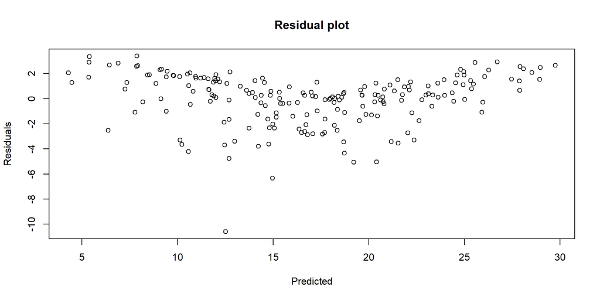

```r
plot(y = resid(model), x = predict(model), xlab = "Predicted", ylab="Residuals", main = "Residual plot")
```

Find the *p*-values of the model and report them as an atomic vector `pvals`. Why would you want to do this? (Use `str` on the model summary.)

```r
summary_model <- summary(model)
```

```r
pvals <- summary_model$coefficients[,4]
```

## Plotting the model

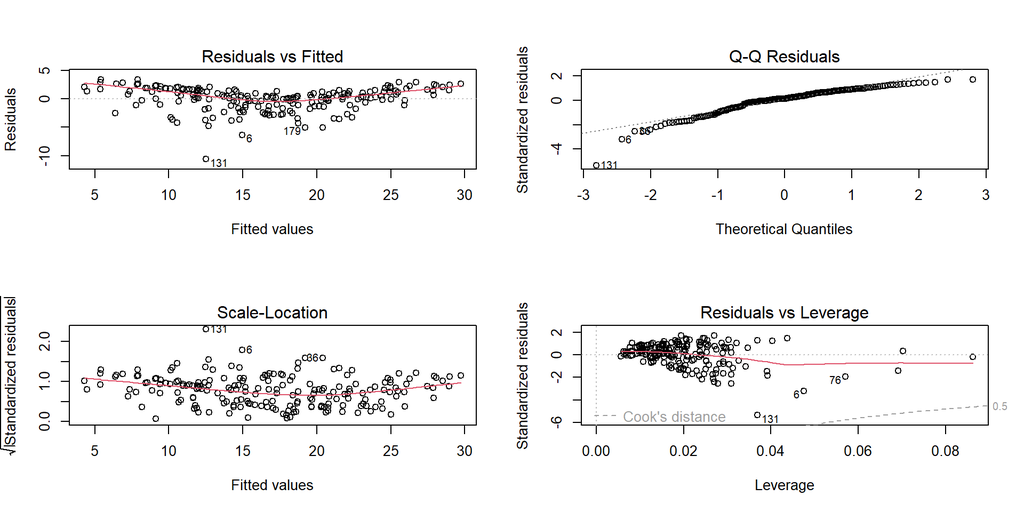

```r
par(mfrow=c(2,2))
plot(model)
```

## Improving the model

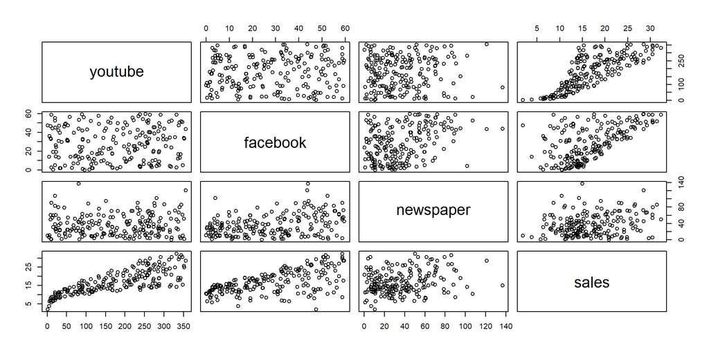

```r
pairs(marketing)
```

The relationship between `sales` and `youtube` appears logarithmic. (And heteroskedastic.)

```r
min(marketing$youtube)
```

```
[1] 0.84
```

## Log transform

```r
model_log <- lm(sales ~ log(youtube) + facebook, data = marketing)
```

```r
summary(model_log)
```

```
Call:
lm(formula = sales ~ log(youtube) + facebook, data = marketing)

Residuals:
    Min      1Q  Median      3Q     Max
-5.0060 -1.1189 -0.2763  0.9496  6.0461

Coefficients:
               Estimate Std. Error t value Pr(>|t|)
(Intercept)  -11.821771   0.707550  -16.71   <2e-16 ***
log(youtube)   4.720509   0.135621   34.81   <2e-16 ***
facebook       0.205384   0.007653   26.84   <2e-16 ***
---
Signif. codes:  0 '***' 0.001 '**' 0.01 '*' 0.05 '.' 0.1 ' ' 1

Residual standard error: 1.923 on 197 degrees of freedom
Multiple R-squared:  0.9066,    Adjusted R-squared:  0.9056
F-statistic: 955.8 on 2 and 197 DF,  p-value: < 2.2e-16
```

## Plot

- Plot
- Exercise
- Solution

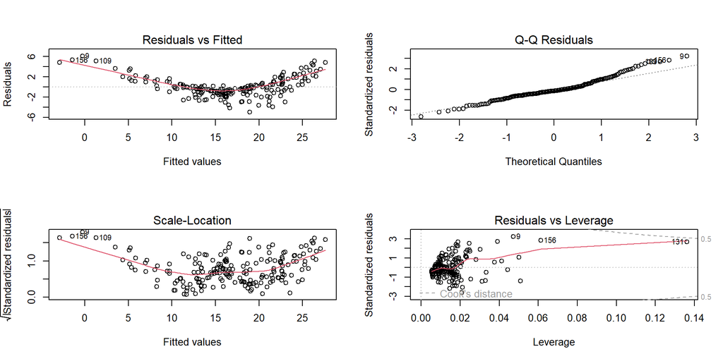

```r
par(mfrow=c(2,2))
plot(model_log)
```

> See if you can improve the model further by adding a linear term `youtube` to the regression model formula. Investigate the adjusted $R^2$ and the residual plots.

```r
model_log_slope <- lm(sales ~ youtube + log(youtube) + facebook, data = marketing)
summary(model_log_slope)$adj.r.squared
```

```
[1] 0.9342393
```

## Plot

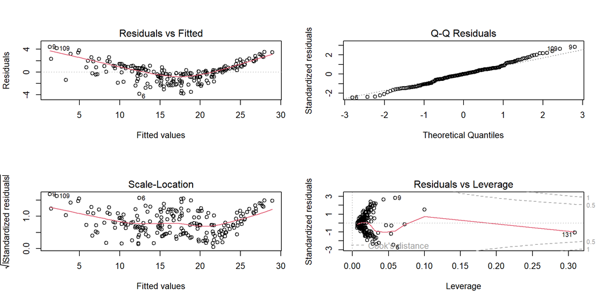

```r
par(mfrow=c(2,2))
plot(model_log_slope)
```

# Logistic regression

## Titanic

Consider the famous Titanic data set

```r
titanic <- datarium::titanic.raw
head(titanic)
```

```
  Class  Sex   Age Survived
1   3rd Male Child       No
2   3rd Male Child       No
3   3rd Male Child       No
4   3rd Male Child       No
5   3rd Male Child       No
6   3rd Male Child       No
```

## Logistic regression

```r
model_titanic <- glm(
  Survived ~ Class + Sex + Age,
  data = titanic,
  family=binomial(link="logit"))
```

```r
summary(model_titanic)
```

```
Call:
glm(formula = Survived ~ Class + Sex + Age, family = binomial(link = "logit"),
    data = titanic)

Coefficients:
            Estimate Std. Error z value Pr(>|z|)
(Intercept)   0.6853     0.2730   2.510   0.0121 *
Class2nd     -1.0181     0.1960  -5.194 2.05e-07 ***
Class3rd     -1.7778     0.1716 -10.362  < 2e-16 ***
ClassCrew    -0.8577     0.1573  -5.451 5.00e-08 ***
SexFemale     2.4201     0.1404  17.236  < 2e-16 ***
AgeAdult     -1.0615     0.2440  -4.350 1.36e-05 ***
---
Signif. codes:  0 '***' 0.001 '**' 0.01 '*' 0.05 '.' 0.1 ' ' 1

(Dispersion parameter for binomial family taken to be 1)

    Null deviance: 2769.5  on 2200  degrees of freedom
Residual deviance: 2210.1  on 2195  degrees of freedom
AIC: 2222.1

Number of Fisher Scoring iterations: 4
```

## Interaction term

```r
model_titanic_interact <- glm(
  Survived ~ Class + Sex * Age,
  data = titanic,
  family=binomial(link="logit"))
```

```r
summary(model_titanic_interact)
```

```
Call:
glm(formula = Survived ~ Class + Sex * Age, family = binomial(link = "logit"),
    data = titanic)

Coefficients:
                   Estimate Std. Error z value Pr(>|z|)
(Intercept)          1.3565     0.3033   4.473 7.71e-06 ***
Class2nd            -1.0338     0.1998  -5.174 2.29e-07 ***
Class3rd            -1.8105     0.1759 -10.291  < 2e-16 ***
ClassCrew           -0.8033     0.1598  -5.027 4.99e-07 ***
SexFemale            0.7151     0.4062   1.760   0.0784 .
AgeAdult            -1.7921     0.2829  -6.334 2.38e-10 ***
SexFemale:AgeAdult   1.9021     0.4331   4.392 1.12e-05 ***
---
Signif. codes:  0 '***' 0.001 '**' 0.01 '*' 0.05 '.' 0.1 ' ' 1

(Dispersion parameter for binomial family taken to be 1)

    Null deviance: 2769.5  on 2200  degrees of freedom
Residual deviance: 2192.0  on 2194  degrees of freedom
AIC: 2206

Number of Fisher Scoring iterations: 4
```

## Anova table

- ANOVA
- Exercise
- Solution
- Exercise
- Solution

We can run an ANOVA to find if the interaction is significant.

```r
anova(model_titanic, model_titanic_interact)
```

```
Analysis of Deviance Table

Model 1: Survived ~ Class + Sex + Age
Model 2: Survived ~ Class + Sex * Age
  Resid. Df Resid. Dev Df Deviance  Pr(>Chi)
1      2195     2210.1
2      2194     2192.0  1   18.018 2.188e-05 ***
---
Signif. codes:  0 '***' 0.001 '**' 0.01 '*' 0.05 '.' 0.1 ' ' 1
```

Using the tools we just covered, investigate if there is a significant interaction effect between `Sex` and `Class`. (Compare to the model with an interaction between `Sex` and `Age`.)

```r
model_titanic_interact_class <- glm(
  Survived ~ Class + Sex * Age + Sex * Class,
  data = titanic,
  family=binomial(link="logit"))
anova(model_titanic, model_titanic_interact, model_titanic_interact_class)
```

```
Analysis of Deviance Table

Model 1: Survived ~ Class + Sex + Age
Model 2: Survived ~ Class + Sex * Age
Model 3: Survived ~ Class + Sex * Age + Sex * Class
  Resid. Df Resid. Dev Df Deviance  Pr(>Chi)
1      2195     2210.1
2      2194     2192.0  1   18.018 2.188e-05 ***
3      2191     2134.8  3   57.286 2.233e-12 ***
---
Signif. codes:  0 '***' 0.001 '**' 0.01 '*' 0.05 '.' 0.1 ' ' 1
```

- Recall (or get to know!) that a probit regression is a binary regression model, i.e., a generalized linear model (glm) with a binomial family.
- By investigating the documentation of `binomial`, figure out how to run a probit regression. Run the interaction analysis with probit instead of logit.
- Evaluate the models using the `AIC` generic. (Lower is better.)

```r
model_titanic_interact_probit <- glm(
  Survived ~ Class + Sex * Age,
  data = titanic,
  family=binomial(link="probit"))
AIC(model_titanic_interact)
```

```
[1] 2206.043
```

```r
AIC(model_titanic_interact_probit)
```

```
[1] 2209.976
```

Smaller AIC is better. So logit is best!